# US 2016 Presidential election analysis

**2016 US Presidential Election Results Analysis**

[figure not shown]

**Name of author:** Hans Peter Ndeffo

**Department:** Mathematics

**Date:** 3/23/2019

**Summary**

```
The results of US 2016 presidential election surprised many people throughout the world. Hillary Clinton was the favorite candidate with potentially the

highest number of voters based on preliminary analysis. Therefore, how can Donald Trump can outclass all the predictions against him and win? The purpose of

this report is, consequently, to establish if the outcome of the election has been influenced by Russia hacking or it is natural. Our null hypothesis is the US

presidential election has been hacked by Russia.
```

**Procedure:**

[output not shown]

 *Getting 10 last US presidential election votes the including US presidential election.*

 *Defining the model, variables and dependencies between if there is.*

 *Looking for the best model(linear, polynomial regression) that can be used to predict the 2016 US presidential election. What is important to note is that the more US presidential elections included in the analysis*

*the better the prediction should be. Also the choice of the best model will be based on the split and train technic and further details will be given later*

 *Getting the US 2016 presidential election tally per states.*

 *Pre-process the data using numpy, sklearn to check for empty rows or columns.*

 *Sorting the data using R studio to get only the last digit from 0 to 9 of the total number of voters of each states and count how many times they appear.*

 *Use the Chi-Squared to see if the vote tally is uniformly distributed based on the previous elections distribution. That will determine if there is a fraud or not with confidence level of 95%*

 *Conclude*

**Contents**

Summary

Getting the data

Sorting and counting

Accepting or rejecting the result using Chi-Squared test

Conclusion

Appendix A:

References

```python
# Import the libraries
import numpy as np
import pandas as pd
from sklearn import svm
import matplotlib.pyplot as plt
```

**An excel file or table that has all the us presidential elections will be imported**

Lets have a look at the table

```python
dataset0 = pd.read_csv("US Elections Result.csv")
dataset0.iloc[:,0:-1]
```

|  | Election year | Main Candidates | Main Party | Popular Votes |
| --- | --- | --- | --- | --- |
| 0 | 2016 | Donald J. Trump | Republican | 62980160 |
| 1 | 2016 | Hillary R. Clinton | Democratic | 65845063 |
| 2 | 2012 | W. Mitt Romney | Republican | 60589084 |
| 3 | 2012 | Barack H. Obama | Democratic | 65446032 |
| 4 | 2008 | John S. McCain | Republican | 59934814 |
| 5 | 2008 | Barack H. Obama | Democratic | 69456897 |
| 6 | 2004 | George W. Bush | Republican | 62039073 |
| 7 | 2004 | John F. Kerry | Democratic | 59027478 |
| 8 | 2000 | George W. Bush | Republican | 50456062 |
| 9 | 2000 | Albert Gore, Jr. | Democratic | 50996582 |
| 10 | 1996 | Robert Dole | Republican | 37816307 |
| 11 | 1996 | William J. Clinton | Democratic | 45590703 |
| 12 | 1992 | George Bush | Republican | 39102343 |
| 13 | 1992 | William J. Clinton | Democratic | 44908254 |
| 14 | 1988 | George Bush | Republican | 47946000 |
| 15 | 1988 | Michael S. Dukakis | Democratic | 41016000 |
| 16 | 1984 | Ronald Reagan | Republican | 54455000 |
| 17 | 1984 | Walter F. Mondale | Democratic | 37577000 |
| 18 | 1980 | Ronald Reagan | Republican | 43901812 |
| 19 | 1980 | Jimmy Carter | Democratic | 35483820 |
| 20 | 1976 | Gerald R. Ford | Republican | 40825839 |
| 21 | 1976 | Jimmy Carter | Democratic | 39147770 |

### Defining the model

**Assumptions:**

-The number of votes strongly depends on the states and the number of people that have voted that year in that state

-

**Variables:**

- Number of votes obtain in a year for a given state: It is a variable because it is not known it is what this analysis aims to predict

```python
#Create a list that contains the elections year that will be used for the plot
years = []

for i in range(11):
    years.append(1976 + 4*i)

# Display the list
years
```

```
[1976, 1980, 1984, 1988, 1992, 1996, 2000, 2004, 2008, 2012, 2016]
```

```python
dataset0.iloc[2*0:2*0+1,3].values[0]
```

```
62980160
```

```python
#NoOfVotes = dataset0.iloc[:,3].values

# Number of votes for the republican candidate
repNoOfVotes = []
# Number of votes for the democrate candidate
demNoOfVotes = []

# Get the number of votes from the republican candidate according to the table above
for i in range(len(years)):
    # Append the corresponding vote to the appropriate candidate
    repNoOfVotes.append(dataset0.iloc[2*i:2*i+1,3].values[0])
    demNoOfVotes.append(dataset0.iloc[2*i+1:2*i+2,3].values[0])
```

```python
# indexes will be generates to plots the states names on the x-axis
index0 = np.arange(len(years))
index0
```

```
array([ 0,  1,  2,  3,  4,  5,  6,  7,  8,  9, 10])
```

[figure not shown]

```python
p1 = plt.scatter(index0,repNoOfVotes,label="Rep Votes of a given year")
p2 = plt.scatter(index0,demNoOfVotes,color = 'red',label="Dem Votes of a given year")
#plt.bar(index0,repNoOfVotes)
plt.xlabel('Year',fontsize=5)
plt.ylabel('No of Votes',fontsize=5)
plt.xticks(index0,years, fontsize = 5, rotation=90)
plt.legend(loc="best")

plt.show()
```

```python
votingYears = []
for i in range (11):
    nextVotingYear = [i]
    votingYears.append(nextVotingYear)
votingYears
```

```
[[0], [1], [2], [3], [4], [5], [6], [7], [8], [9], [10]]
```

```python
X = np.array(votingYears)
y = np.array(demNoOfVotes)
yPredict = svm.SVR().fit(X, y).predict(X)
yPredict
```

```
array([45590704.3863186 , 45590704.75419793, 45590704.77239005,
       45590704.75407441, 45590704.36787944, 45590703.        ,
       45590701.63212056, 45590701.24592559, 45590701.22760995,
       45590701.24580207, 45590701.6136814 ])
```

```python
demNoOfVotes
```

```
[65845063,
 65446032,
 69456897,
 59027478,
 50996582,
 45590703,
 44908254,
 41016000,
 37577000,
 35483820,
 39147770]
```

```
array([50458633.80012227, 50458941.78681409, 50458575.27497225,
       50457517.87127753, 50456061.99999931, 50454675.91758583,
       50453737.66961543, 50453339.15775471, 50453329.24795792,
       50453525.56486255, 50453852.00421544])
```

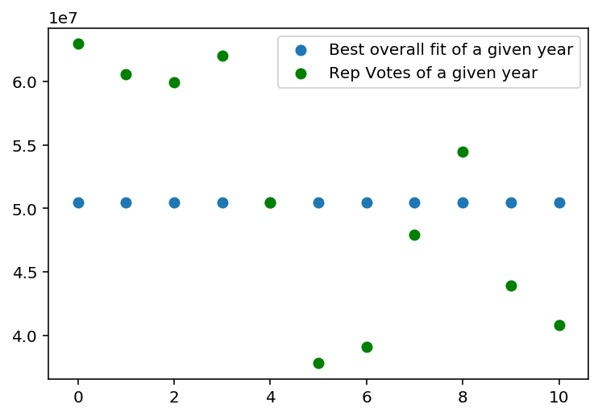

```python
X = np.array(votingYears)
y = np.array(repNoOfVotes)
svr_rbf = svm.SVR(kernel='rbf', C=1e3, gamma=0.1)
yPredict = svr_rbf.fit(X, y) .predict(X)
p3 = plt.scatter(index0,yPredict,label="Best overall fit of a given year")
p4 = plt.scatter(index0,repNoOfVotes, color = 'green',label="Rep Votes of a given year")
plt.legend(loc="best")
#plt.show()
yPredict
```

```python
# Import train_test_split function
from sklearn.model_selection import train_test_split

X_train, X_test, y_train, y_test = train_test_split(index0, repNoOfVotes, test_size=0.3,random_state=40) # 70% of data will be use for training and 30% for testing
```

This simply means that a part of the data will be used to predict the outcome of the 30%

remaining. This technique is commonly used to predict data based on the others. The X train, Xtest and Y train, Y test are split the same the way as shown as below. However the size

of the training data depends and may vary from 1 testing to another one. However if it is

possible to predict outcomes from testing data from a really small training set, it means that

the model that has been built is relatively robust.

```python
# Each number such as 1 stands for 1980, 2 for 1984
X_train
```

```
array([1, 2, 9, 0, 5, 7, 6])
```

```python
X_test
```

```
array([ 3,  4,  8, 10])
```

```python
y_train
```

```
[60589084, 59934814, 43901812, 62980160, 37816307, 47946000, 39102343]
```

```python
y_test
```

```
[62039073, 50456062, 54455000, 40825839]
```

```python
for i in range (len(repNoOfVotes)):
    print(str(repNoOfVotes[i]) + " with an index " + str(i) + " which represents the year " + str(years[i]))
```

[output not shown]

```python
# Creating an array for the X train set
votingYearsTrain = []
for i in range (len(X_train)):
    # Append the voting year corresponding to i
    if i in X_train:
        nextVotingYearTrain = [i]
        votingYearsTrain.append(nextVotingYearTrain)
votingYearsTrain
```

```
[[0], [1], [2], [5], [6]]
```

Now the variable **votingYearsTrain** is **ready to be used in the svm function**

```python
# Creating an array for the X train set
repVotingTrainSet = []
for i in range (len(y_train)):
    # Append the voting year corresponding to i
    if repNoOfVotes[i] in y_train:
        nextVoteInTrain = repNoOfVotes[i]
        repVotingTrainSet.append(nextVoteInTrain)
repVotingTrainSet
```

```
[62980160, 60589084, 59934814, 37816307, 39102343]
```

Now the variable **repVotingTrainSet** is **ready to be used in the svm function**

```
array([59935642.7374116 , 59935468.16461605, 59934814.00000096,
       59932226.45281321, 59932051.88001766])
```

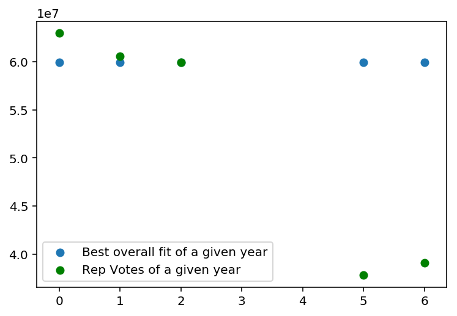

```python
X = np.array(votingYearsTrain)
y = np.array(repVotingTrainSet)
svr_rbf = svm.SVR(kernel='rbf', C=1e3, gamma=0.1)
yPredict = svr_rbf.fit(X, y) .predict(X)
p3 = plt.scatter(votingYearsTrain,yPredict,label="Best overall fit of a given year")
p4 = plt.scatter(votingYearsTrain,repVotingTrainSet, color = 'green',label="Rep Votes of a given year")
plt.legend(loc="best")
#plt.show()
yPredict
```

```python
dataset = pd.read_csv("nytimes_presidential_elections_2016_results_county.csv")
dataset
```

|  | Clinton | Trump | Rpt | State | Vote by county | Vote by town | Place |
| --- | --- | --- | --- | --- | --- | --- | --- |
| 0 | 151581.0 | 130614.0 | 100 | Alabama | Jefferson | NaN | Jefferson |
| 1 | 68429.0 | 91087.0 | 100 | Alabama | Mobile | NaN | Mobile |
| 2 | 62435.0 | 89199.0 | 100 | Alabama | Madison | NaN | Madison |
| 3 | 22927.0 | 72846.0 | 100 | Alabama | Shelby | NaN | Shelby |
| 4 | 58669.0 | 33928.0 | 100 | Alabama | Montgomery | NaN | Montgomery |
| 5 | 18409.0 | 72780.0 | 100 | Alabama | Baldwin | NaN | Baldwin |
| 6 | 31746.0 | 47701.0 | 100 | Alabama | Tuscaloosa | NaN | Tuscaloosa |
| 7 | 20987.0 | 34321.0 | 100 | Alabama | Lee | NaN | Lee |
| 8 | 11216.0 | 37392.0 | 100 | Alabama | Morgan | NaN | Morgan |
| 9 | 13197.0 | 32803.0 | 100 | Alabama | Calhoun | NaN | Calhoun |
| 10 | 10350.0 | 32132.0 | 100 | Alabama | Etowah | NaN | Etowah |
| 11 | 10547.0 | 30567.0 | 100 | Alabama | Houston | NaN | Houston |
| 12 | 9340.0 | 28824.0 | 100 | Alabama | Limestone | NaN | Limestone |
| 13 | 9877.0 | 27735.0 | 100 | Alabama | Lauderdale | NaN | Lauderdale |
| 14 | 5550.0 | 31579.0 | 100 | Alabama | St. Clair | NaN | St. Clair |
| 15 | 3730.0 | 32734.0 | 100 | Alabama | Cullman | NaN | Cullman |
| 16 | 8436.0 | 27619.0 | 100 | Alabama | Elmore | NaN | Elmore |
| 17 | 4913.0 | 29217.0 | 100 | Alabama | Marshall | NaN | Marshall |
| 18 | 12108.0 | 20596.0 | 100 | Alabama | Talladega | NaN | Talladega |
| 19 | 4486.0 | 24208.0 | 100 | Alabama | Walker | NaN | Walker |
| 20 | 3682.0 | 21779.0 | 100 | Alabama | DeKalb | NaN | DeKalb |
| 21 | 2150.0 | 22808.0 | 100 | Alabama | Blount | NaN | Blount |
| 22 | 5908.0 | 18110.0 | 100 | Alabama | Autauga | NaN | Autauga |
| 23 | 7296.0 | 16718.0 | 100 | Alabama | Colbert | NaN | Colbert |
| 24 | 3663.0 | 16643.0 | 100 | Alabama | Jackson | NaN | Jackson |
| 25 | 4194.0 | 15825.0 | 100 | Alabama | Coffee | NaN | Coffee |
| 26 | 9577.0 | 9210.0 | 100 | Alabama | Russell | NaN | Russell |
| 27 | 12826.0 | 5784.0 | 100 | Alabama | Dallas | NaN | Dallas |
| 28 | 4408.0 | 13798.0 | 100 | Alabama | Dale | NaN | Dale |
| 29 | 5271.0 | 12967.0 | 100 | Alabama | Tallapoosa | NaN | Tallapoosa |
| ... | ... | ... | ... | ... | ... | ... | ... |
| 4554 | 2171.0 | 4564.0 | 100 | Wisconsin | Rusk | NaN | Rusk |
| 4555 | 2531.0 | 4049.0 | 100 | Wisconsin | Buffalo | NaN | Buffalo |
| 4556 | 1583.0 | 2787.0 | 100 | Wisconsin | Forest | NaN | Forest |
| 4557 | 1345.0 | 2228.0 | 100 | Wisconsin | Pepin | NaN | Pepin |
| 4558 | 1273.0 | 2090.0 | 100 | Wisconsin | Iron | NaN | Iron |
| 4559 | 666.0 | 1897.0 | 100 | Wisconsin | Florence | NaN | Florence |
| 4560 | 1003.0 | 269.0 | 100 | Wisconsin | Menominee | NaN | Menominee |
| 4561 | 11572.0 | 24844.0 | 100 | Wyoming | Laramie | NaN | Laramie |
| 4562 | 6573.0 | 23523.0 | 100 | Wyoming | Natrona | NaN | Natrona |
| 4563 | 1324.0 | 15778.0 | 100 | Wyoming | Campbell | NaN | Campbell |
| 4564 | 3233.0 | 12153.0 | 100 | Wyoming | Sweetwater | NaN | Sweetwater |
| 4565 | 4200.0 | 11167.0 | 100 | Wyoming | Fremont | NaN | Fremont |
| 4566 | 6888.0 | 7601.0 | 100 | Wyoming | Albany | NaN | Albany |
| 4567 | 2535.0 | 11115.0 | 100 | Wyoming | Park | NaN | Park |
| 4568 | 2926.0 | 10266.0 | 100 | Wyoming | Sheridan | NaN | Sheridan |
| 4569 | 7313.0 | 3920.0 | 100 | Wyoming | Teton | NaN | Teton |
| 4570 | 1105.0 | 6779.0 | 100 | Wyoming | Lincoln | NaN | Lincoln |
| 4571 | 1202.0 | 6154.0 | 100 | Wyoming | Uinta | NaN | Uinta |
| 4572 | 668.0 | 5520.0 | 100 | Wyoming | Converse | NaN | Converse |
| 4573 | 1279.0 | 4409.0 | 100 | Wyoming | Carbon | NaN | Carbon |
| 4574 | 924.0 | 4418.0 | 100 | Wyoming | Goshen | NaN | Goshen |
| 4575 | 594.0 | 4067.0 | 100 | Wyoming | Big Horn | NaN | Big Horn |
| 4576 | 719.0 | 3437.0 | 100 | Wyoming | Platte | NaN | Platte |
| 4577 | 638.0 | 3477.0 | 100 | Wyoming | Johnson | NaN | Johnson |
| 4578 | 644.0 | 3409.0 | 100 | Wyoming | Sublette | NaN | Sublette |
| 4579 | 271.0 | 3347.0 | 100 | Wyoming | Crook | NaN | Crook |
| 4580 | 532.0 | 2911.0 | 100 | Wyoming | Washakie | NaN | Washakie |
| 4581 | 294.0 | 2898.0 | 100 | Wyoming | Weston | NaN | Weston |
| 4582 | 400.0 | 1939.0 | 100 | Wyoming | Hot Springs | NaN | Hot Springs |
| 4583 | 115.0 | 1116.0 | 100 | Wyoming | Niobrara | NaN | Niobrara |

4584 rows × 7 columns

It can be seen the data are sorted but the total vote counts does not appear for each states.

**The first part of this analysis will be to organize and count the vote for each states**

```python
# Getting the states participating into the vote from the file
# The third represents the states but that column has duplicates states' name
label = dataset.iloc[:, 3].values
states = []

for i in range(len(label)):
    if i < len(label) - 2:
        # Getting one state's name and avoiding duplicates
        if label[i] != label[i+1]:
            states.append(label[i])
# Append the last state into the list
states.append(label[len(label)-1])

# Show the states
print(states)
```

```
['Alabama', 'Arizona', 'Arkansas', 'California', 'Colorado', 'Connecticut', 'Delaware', 'Florida', 'Georgia', 'Hawaii', 'Idaho', 'Illinois', 'Indiana', 'Iowa', 'Kansas', 'Kentucky', 'Louisiana', 'Maine', 'Maryland', 'Massachusetts', 'Michigan', 'Minnesota', 'Mississippi', 'Missouri', 'Montana', 'Neb…
```

```python
votes = []
votes.append(states)
print(votes)
```

```
[['Alabama', 'Arizona', 'Arkansas', 'California', 'Colorado', 'Connecticut', 'Delaware', 'Florida', 'Georgia', 'Hawaii', 'Idaho', 'Illinois', 'Indiana', 'Iowa', 'Kansas', 'Kentucky', 'Louisiana', 'Maine', 'Maryland', 'Massachusetts', 'Michigan', 'Minnesota', 'Mississippi', 'Missouri', 'Montana', 'Ne…
```

```python
# if 0 is passed then it will count the votes for Clinton and if it will count the votes for Trump
def countVotes(canditate):

    # The total number of states that appear in the csv file is 48. Therefore a 2 dimensional array will be enough to store all the votes
    votePerState = []
    votePerState.append(states)

    # Get the votes column
    vote = dataset.iloc[:,canditate].values
    j = 0

    # Create an empty list to save the vote count for each states
    voteCount = [0]*49

    #Count the vote per state
    for i in range(len(label) - 1):
        if i < len(label) - 2:
            if label[i] == label[i+1]:
                voteCount[j] = voteCount[j] + vote[i] + vote[i+1]
            else:
                j = j + 1

    votePerState.append(voteCount)
    return votePerState

votes = countVotes(0)
print(votes)
```

```
[['Alabama', 'Arizona', 'Arkansas', 'California', 'Colorado', 'Connecticut', 'Delaware', 'Florida', 'Georgia', 'Hawaii', 'Idaho', 'Illinois', 'Indiana', 'Iowa', 'Kansas', 'Kentucky', 'Louisiana', 'Maine', 'Maryland', 'Massachusetts', 'Michigan', 'Minnesota', 'Mississippi', 'Missouri', 'Montana', 'Ne…
```

```python
# indexes will be generates to plots the states names on the x-axis
index1 = np.arange(len(states))
ind = np.arange(len(votes[1]))
index1
```

```
array([ 0,  1,  2,  3,  4,  5,  6,  7,  8,  9, 10, 11, 12, 13, 14, 15, 16,
       17, 18, 19, 20, 21, 22, 23, 24, 25, 26, 27, 28, 29, 30, 31, 32, 33,
       34, 35, 36, 37, 38, 39, 40, 41, 42, 43, 44, 45, 46, 47, 48])
```

```python
# Plot function to have an overall view of the results
def barPlot(x,y,candidate,candidateName):
    plt.bar(x,y)
    plt.xlabel('States',fontsize=5)
    plt.ylabel('No of Votes',fontsize=5)
    plt.xticks(index1,states, fontsize = 3.5, rotation=90)
    plt.title(candidateName + ' votes per states')
    plt.show()
```

# Clinton votes per states

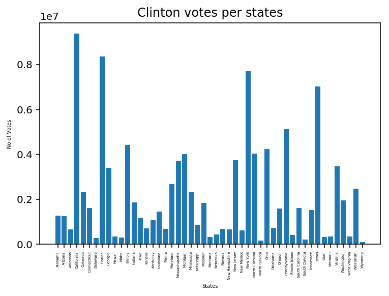

```python
barPlot(index1,votes[1],0,'Clinton')
```

# Trump votes per states

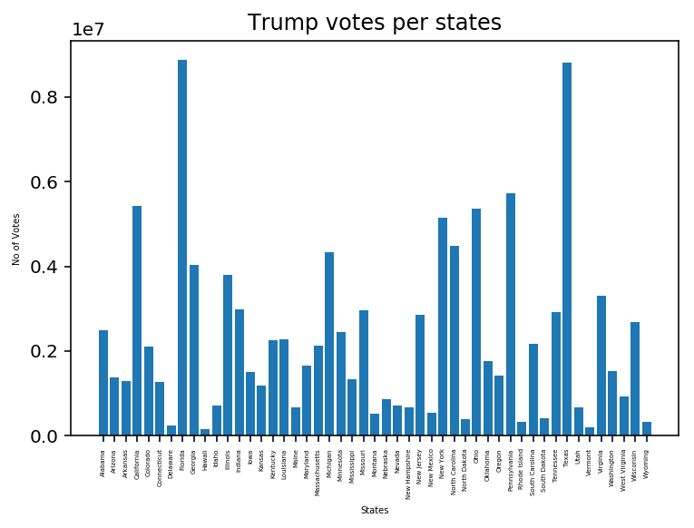

```python
votes2 = countVotes(1)
barPlot(index1,votes2[1],1,'Trump')
```

**As it can be seen the distribution of the votes are similar that might indicate that there is may be not a huge difference in the results**

However in order to make a prediction the results of one election is not enough because it does not provide information to any model, such as linear regression.

Therefore it is reasonable to think in order to make a better prediction it is required to have as many election results for republicans and democrats.

Thus the more election results are involved the better the prediction should be.

So the next part will be to import those data and use some of them to train our model.